# Week 5 Assignment

Monu Chacko

March 2, 2019

## Assignment– Tidying and Transforming Data

### (1) Create a .CSV file (or optionally, a MySQL database!) that includes all of the information above. You’re encouraged to use a “wide” structure similar to how the information appears above, so that you can practice tidying and transformations as described below.

### (2) Read the information from your .CSV file into R, and use tidyr and dplyr as needed to tidy and transform your data.

### (3) Perform analysis to compare the arrival delays for the two airlines.

### (4) Your code should be in an R Markdown file, posted to rpubs.com, and should include narrative descriptions of your data cleanup work, analysis,and conclusions.Please include in your homework submission:TheURLto the .Rmd file in your GitHub repository.and T heURL for your rpubs.com web page.

```r
library("readxl")
library("tidyr")
library("dplyr")
library("Hmisc")
library("ggplot2")

#Read from excel file
dfAirlinesDataXl <- read_excel("airlines_data_5.xlsx", na="")
dfAirlinesDataXl
```

```
## # A tibble: 5 x 7
##   X__1    X__2    `Los Angeles` Phoenix `San Diego` `San Franciso` Seattle
##   <chr>   <chr>           <dbl>   <dbl>       <dbl>          <dbl>   <dbl>
## 1 ALASKA  on time           497     221         212            503    1841
## 2 <NA>    delayed            62      12          20            102     305
## 3 <NA>    <NA>               NA      NA          NA             NA      NA
## 4 AM WEST on time           694    4840         383            320     201
## 5 <NA>    delayed           117     415          65            129      61
```

```r
#Find the datatype of dfAirlinesData before we do cleanup
typeof(dfAirlinesDataXl)
```

```
## [1] "list"
```

```r
#Convert to data frame
dfAirlinesData <- data.frame(dfAirlinesDataXl)
```

```r
#View the data to see what has to be cleaned up
dfAirlinesData
```

```
##      X__1    X__2 Los.Angeles Phoenix San.Diego San.Franciso Seattle
## 1  ALASKA on time         497     221       212          503    1841
## 2    <NA> delayed          62      12        20          102     305
## 3    <NA>    <NA>          NA      NA        NA           NA      NA
## 4 AM WEST on time         694    4840       383          320     201
## 5    <NA> delayed         117     415        65          129      61
```

```r
#Rename columns to readable names
dfAirlinesData <- dfAirlinesData %>%
  filter(!is.na(n)) %>%
  rename(airline = X__1, status = X__2, los_angeles = Los.Angeles, phoenix = Phoenix, san_diego = San.Diego, san_franciso = San.Franciso, seattle = Seattle)
dfAirlinesData
```

[output not shown]

```r
#Remove NA and smooth data further
dfAirlinesData <- dfAirlinesData[-c(3),]

#Add missing values
dfAirlinesData[2, "airline"] <- "ALASKA"
dfAirlinesData[4, "airline"] <- "AM WEST"

#Reset index
rownames(dfAirlinesData) <- NULL

#Add factor
dfAirlinesData$airline <- factor(dfAirlinesData$airline)

dfAirlinesData
```

```
##   airline  status los_angeles phoenix san_diego san_franciso seattle
## 1  ALASKA on time         497     221       212          503    1841
## 2  ALASKA delayed          62      12        20          102     305
## 3 AM WEST on time         694    4840       383          320     201
## 4 AM WEST delayed         117     415        65          129      61
```

```r
#View column names
names(dfAirlinesData)
```

```
## [1] "airline"      "status"       "los_angeles"  "phoenix"
## [5] "san_diego"    "san_franciso" "seattle"
```

```r
#View datatypes
sapply(dfAirlinesData, typeof)
```

```
##      airline       status  los_angeles      phoenix    san_diego
##    "integer"  "character"     "double"     "double"     "double"
## san_franciso      seattle
##     "double"     "double"
```

```r
#Lets see the stats of the data structure before saving it to csv
describe(dfAirlinesData)
```

```
## dfAirlinesData
##
##  7  Variables      4  Observations
## ---------------------------------------------------------------------------
## airline
##        n  missing distinct
##        4        0        2
##
## Value       ALASKA AM WEST
## Frequency        2       2
## Proportion     0.5     0.5
## ---------------------------------------------------------------------------
## status
##        n  missing distinct
##        4        0        2
##
## Value      delayed on time
## Frequency        2       2
## Proportion     0.5     0.5
## ---------------------------------------------------------------------------
## los_angeles
##        n  missing distinct     Info     Mean      Gmd
##        4        0        4        1    342.5    379.3
##
## Value        62  117  497  694
## Frequency     1    1    1    1
## Proportion 0.25 0.25 0.25 0.25
## ---------------------------------------------------------------------------
## phoenix
##        n  missing distinct     Info     Mean      Gmd
##        4        0        4        1     1372     2446
##
## Value        12  221  415 4840
## Frequency     1    1    1    1
## Proportion 0.25 0.25 0.25 0.25
## ---------------------------------------------------------------------------
## san_diego
##        n  missing distinct     Info     Mean      Gmd
##        4        0        4        1      170      206
##
## Value        20   65  212  383
## Frequency     1    1    1    1
## Proportion 0.25 0.25 0.25 0.25
## ---------------------------------------------------------------------------
## san_franciso
##        n  missing distinct     Info     Mean      Gmd
##        4        0        4        1    263.5    232.3
##
## Value       102  129  320  503
## Frequency     1    1    1    1
## Proportion 0.25 0.25 0.25 0.25
## ---------------------------------------------------------------------------
## seattle
##        n  missing distinct     Info     Mean      Gmd
##        4        0        4        1      602    907.3
##
## Value        61  201  305 1841
## Frequency     1    1    1    1
## Proportion 0.25 0.25 0.25 0.25
## ---------------------------------------------------------------------------
```

### Save data to csv before analysis

```r
write.csv(dfAirlinesData, "./dfAirlinesData.csv", row.names=FALSE)
dfAirlinesCSVStore <- read.csv("./dfAirlinesData.csv",header=TRUE,stringsAsFactors = FALSE)

#Store data in temp variable for reuse
dfAirlinesCSV <- dfAirlinesCSVStore
```

### Analyse the data

```r
#List columns we are going to gather
names(dfAirlinesCSV)[3:7]
```

```
## [1] "los_angeles"  "phoenix"      "san_diego"    "san_franciso"
## [5] "seattle"
```

```r
#Apply and view output
dfAirlinesAn1 <- gather(dfAirlinesCSV, "city", "num", names(dfAirlinesCSV)[3:7], factor_key=TRUE)
dfAirlinesAn1
```

```
##    airline  status         city  num
## 1   ALASKA on time  los_angeles  497
## 2   ALASKA delayed  los_angeles   62
## 3  AM WEST on time  los_angeles  694
## 4  AM WEST delayed  los_angeles  117
## 5   ALASKA on time      phoenix  221
## 6   ALASKA delayed      phoenix   12
## 7  AM WEST on time      phoenix 4840
## 8  AM WEST delayed      phoenix  415
## 9   ALASKA on time    san_diego  212
## 10  ALASKA delayed    san_diego   20
## 11 AM WEST on time    san_diego  383
## 12 AM WEST delayed    san_diego   65
## 13  ALASKA on time san_franciso  503
## 14  ALASKA delayed san_franciso  102
## 15 AM WEST on time san_franciso  320
## 16 AM WEST delayed san_franciso  129
## 17  ALASKA on time      seattle 1841
## 18  ALASKA delayed      seattle  305
## 19 AM WEST on time      seattle  201
## 20 AM WEST delayed      seattle   61
```

```r
dfAirlinesAn1 <-  dfAirlinesAn1 %>%
                 spread(status, `num`)
dfAirlinesAn1
```

```
##    airline         city delayed on time
## 1   ALASKA  los_angeles      62     497
## 2   ALASKA      phoenix      12     221
## 3   ALASKA    san_diego      20     212
## 4   ALASKA san_franciso     102     503
## 5   ALASKA      seattle     305    1841
## 6  AM WEST  los_angeles     117     694
## 7  AM WEST      phoenix     415    4840
## 8  AM WEST    san_diego      65     383
## 9  AM WEST san_franciso     129     320
## 10 AM WEST      seattle      61     201
```

```r
dfAirlinesAn1 <- dfAirlinesAn1 %>%
  mutate(total = delayed + `on time`, percent_delayed = delayed/ total, percent_ontime = `on time`/ total)
dfAirlinesAn1
```

```
##    airline         city delayed on time total percent_delayed
## 1   ALASKA  los_angeles      62     497   559      0.11091234
## 2   ALASKA      phoenix      12     221   233      0.05150215
## 3   ALASKA    san_diego      20     212   232      0.08620690
## 4   ALASKA san_franciso     102     503   605      0.16859504
## 5   ALASKA      seattle     305    1841  2146      0.14212488
## 6  AM WEST  los_angeles     117     694   811      0.14426634
## 7  AM WEST      phoenix     415    4840  5255      0.07897241
## 8  AM WEST    san_diego      65     383   448      0.14508929
## 9  AM WEST san_franciso     129     320   449      0.28730512
## 10 AM WEST      seattle      61     201   262      0.23282443
##    percent_ontime
## 1       0.8890877
## 2       0.9484979
## 3       0.9137931
## 4       0.8314050
## 5       0.8578751
## 6       0.8557337
## 7       0.9210276
## 8       0.8549107
## 9       0.7126949
## 10      0.7671756
```

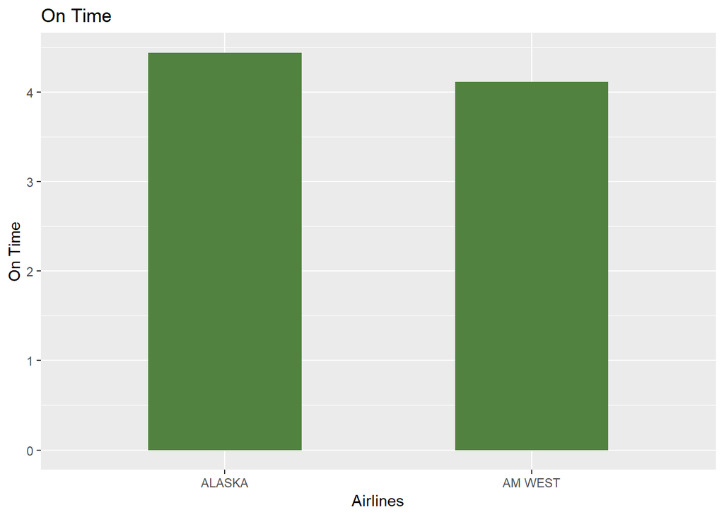

```r
ggplot(data=dfAirlinesAn1, aes(x=airline, y=percent_ontime)) +
  geom_bar(stat="identity", width=0.5, fill="#52823f") +
  xlab("Airlines") + ylab("On Time") +
  ggtitle("On Time")
```

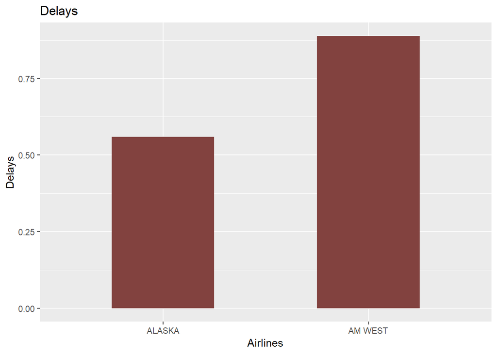

```r
ggplot(data=dfAirlinesAn1, aes(x=airline, y=percent_delayed)) +
  geom_bar(stat="identity", width=0.5, fill="#82423f") +
  xlab("Airlines") + ylab("Delays") +
  ggtitle("Delays")
```

### Observation 1: ALASKA has lesser delayed and more on time flights than AM WEST

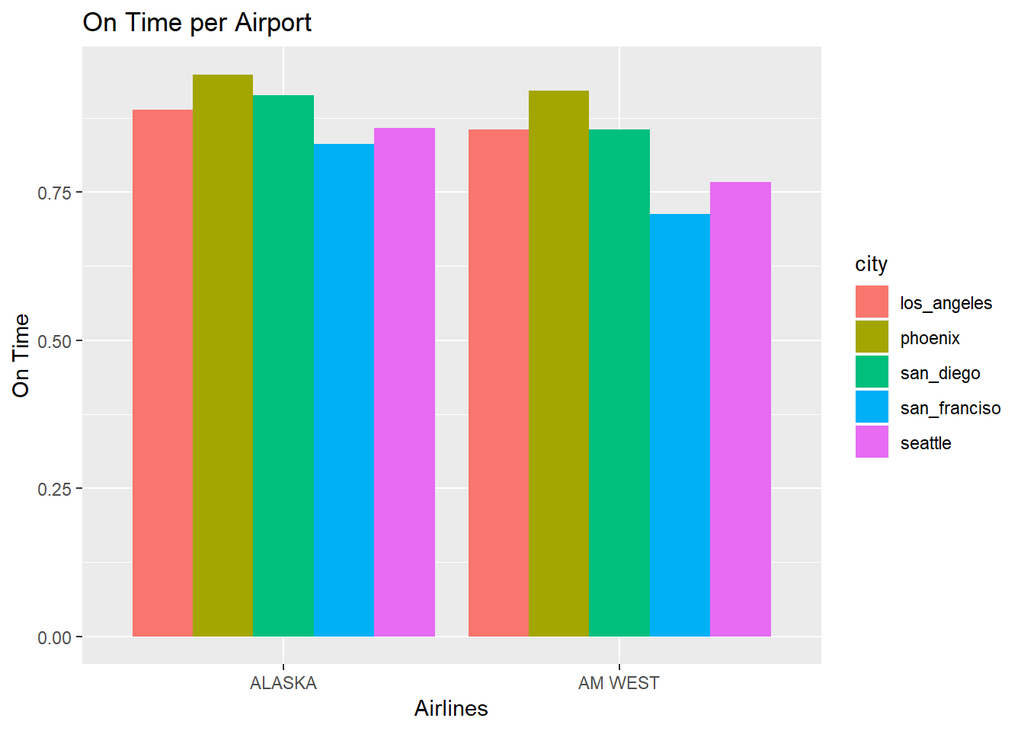

```r
ggplot(data=dfAirlinesAn1, aes(x = airline, y=percent_ontime, fill = city)) +
          geom_bar(stat="identity",position="dodge") +
          xlab("Airlines") + ylab("On Time") + ggtitle("On Time per Airport")
```

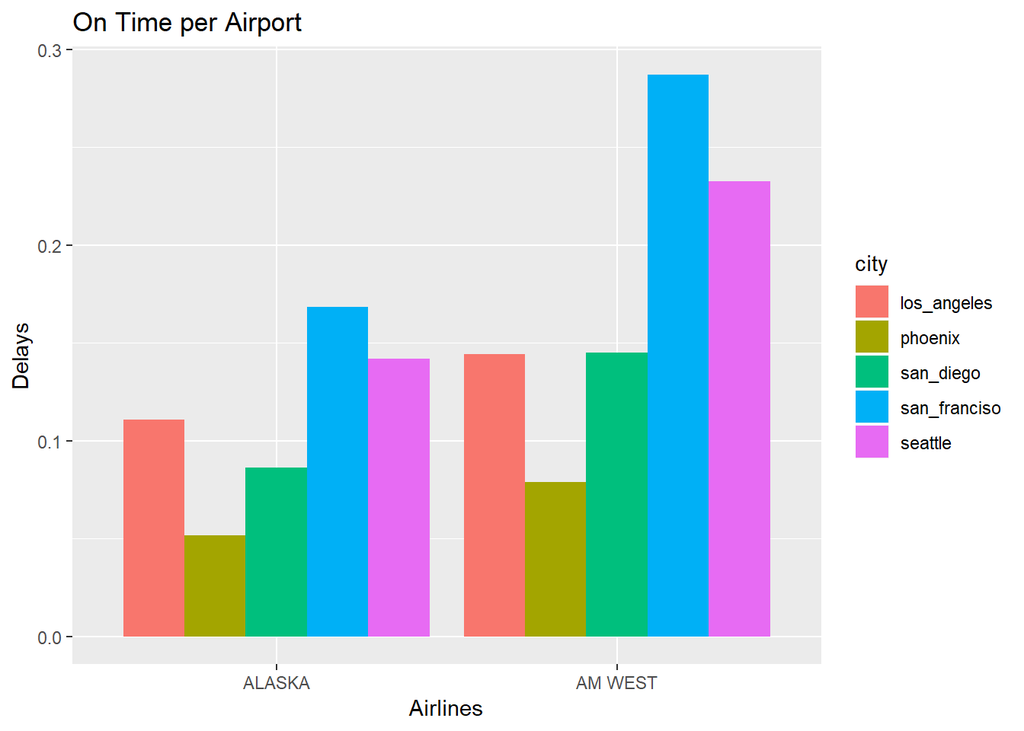

```r
ggplot(data=dfAirlinesAn1, aes(x = airline, y=percent_delayed, fill = city)) +
          geom_bar(stat="identity",position="dodge") +
          xlab("Airlines") + ylab("Delays") + ggtitle("On Time per Airport")
```

### Observation 2: There are more delays in major airports. Could AM WEST be the victim because it operates more flights there than ALASKA? Lets find out.

```r
#Apply and view output
dfAirlinesAn2 <- gather(dfAirlinesCSV, "city", "num", names(dfAirlinesCSV)[3:7], factor_key=TRUE)
dfAirlinesAn2
```

```
##    airline  status         city  num
## 1   ALASKA on time  los_angeles  497
## 2   ALASKA delayed  los_angeles   62
## 3  AM WEST on time  los_angeles  694
## 4  AM WEST delayed  los_angeles  117
## 5   ALASKA on time      phoenix  221
## 6   ALASKA delayed      phoenix   12
## 7  AM WEST on time      phoenix 4840
## 8  AM WEST delayed      phoenix  415
## 9   ALASKA on time    san_diego  212
## 10  ALASKA delayed    san_diego   20
## 11 AM WEST on time    san_diego  383
## 12 AM WEST delayed    san_diego   65
## 13  ALASKA on time san_franciso  503
## 14  ALASKA delayed san_franciso  102
## 15 AM WEST on time san_franciso  320
## 16 AM WEST delayed san_franciso  129
## 17  ALASKA on time      seattle 1841
## 18  ALASKA delayed      seattle  305
## 19 AM WEST on time      seattle  201
## 20 AM WEST delayed      seattle   61
```

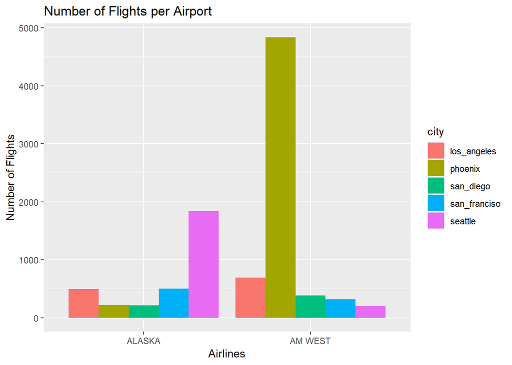

```r
ggplot(data=dfAirlinesAn2, aes(x = airline, y=num, fill = city)) +
          geom_bar(stat="identity",position="dodge") +
          xlab("Airlines") + ylab("Number of Flights") + ggtitle("Number of Flights per Airport")
```

### Observation 3: AM WEST operates lesser flight in larger airport than ALASKA but has more delays. So our hypothesis is in correct.

### Final conclusion: ALASKA seem to have better flight record than AM WEST. There are many factors that could contribute to this. We would need additional datasets to come to a conclusion. Possible reasons could be that ALASKA has an established hub, they could have better reservation system, better flight maintenance etc. These are simply hypothesis at this point and we have to corroborate it with data.